# MODERN STATISTICAL DATA ANALYSIS - Exercise 2 - Question 4-5

Yonatan Hammer, Shmuel Orenstein

```python
import numpy as np
import matplotlib.pyplot as plt
from scipy.stats import norm
import statsmodels.api as statsmodels
```

```python
m=1000
m0=500
mu=2
```

```python
def generate_data_and_pvals(rho=0):
    mus = np.append(np.zeros(m0), mu * np.ones(m - m0))
    s = np.random.normal(0, 1, m)
    s = rho * s[0] + (1 - rho) * s + mus
    return s, norm.sf(s)
```

# Question 4

sections a, b, c

```python
def bh_histograms(n=5000, alpha=0.1):
    r, v, q = np.zeros(n), np.zeros(n), np.zeros(n)
    for rho in [0, 0.95]:
        for i in range(n):
            _, p_vals = generate_data_and_pvals(rho=rho)
            rejected, _, _, _ = statsmodels.stats.multipletests(p_vals, alpha=alpha, method='fdr_bh')
            r[i] = max(np.count_nonzero(rejected), 1)
            v[i] = np.count_nonzero(rejected[:m0])

        plt.hist(r, bins=50)
        plt.title(f"Histogram of R with rho={rho}")
        plt.show()

        plt.hist(v)
        plt.title(f"Histogram of V with rho={rho}")
        plt.show()

        q = v / r
        plt.hist(q, bins=50)
        plt.title(f"Histogram of Q with rho={rho}")
        plt.show()
```

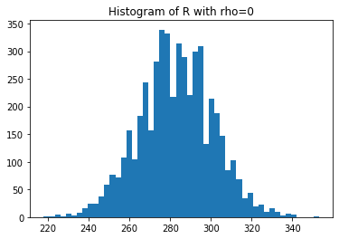

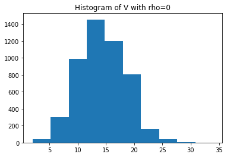

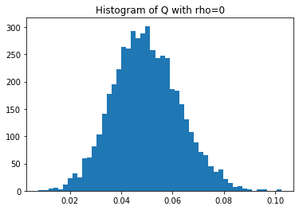

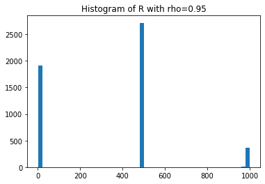

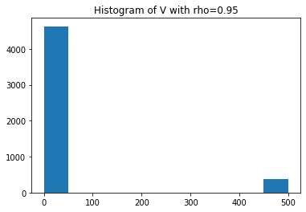

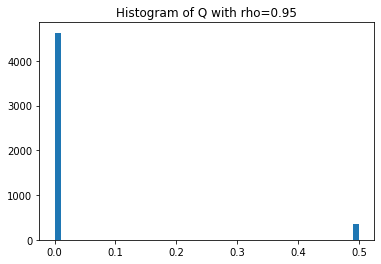

```python
bh_histograms()
```

Regarding R, we can see that for rho=0 the number of rejections distributes like a Gaussian with a center in 280 approximately. When rho=0.95 the number of rejections is distributed in a very different way, while there are only 3 options: reject almost all the hypotheses (R=1000), reject half of them (R=500), or reject almost none of them (R=0).

Regarding V, when rho=0 we have the number of false rejections that distributes like a Gaussian, with a center in 15 approximately. For rho=0.95 V distributes with two options: no false rejections (V=0) or rejection of all the null hypotheses (V=500).

Regarding Q, when rho=0 the relation V/R+ also looks like a Gaussian, and its center is in 0.05. When rho=0.95 we have two main values for Q: Q=0, which means there was no False positive, or Q=0.5, which means a very high number of false positive.

In all the graphs we can see that when rho=0.95 we get a distribution with higher variance.

```python
def bh_graph(n=5000, alpha=0.1):
    rhos = np.arange(0, 1.05, 0.05)
    means = np.zeros(len(rhos))
    stds = np.zeros(len(rhos))

    for j, rho in enumerate(rhos):
        q = np.zeros(n)
        for i in range(n):
            _, p_vals = generate_data_and_pvals(rho=rho)
            rejected, _, _, _ = statsmodels.stats.multipletests(p_vals, alpha=alpha, method='fdr_bh')
            q[i] = np.count_nonzero(rejected[:m0]) / max(np.count_nonzero(rejected), 1)
        means[j] = np.mean(q)
        stds[j] = np.std(q)

    plt.errorbar(rhos, means, stds, linestyle='None', marker='^')
    plt.xticks(rhos)
    plt.title("mean and standard deviation as a function of rho")
    plt.savefig("mean_std_graph")
    plt.show()
```

section d

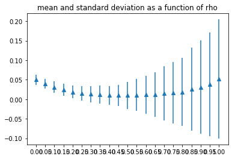

```python
bh_graph()
```

# Question 5

section a

```python
def histogram_and_densities(rho=0, pi_0=0.5):
    x, _ = generate_data_and_pvals(rho=rho)
    plt.hist(x, bins=100, density=True, label="data")
    x_axis = np.linspace(-4, 4, 1000)
    f0 = norm.pdf(x_axis, 0, 1)
    f1 = norm.pdf(x_axis, 2, 1)
    plt.plot(x_axis, pi_0 * f0, label="F0")
    plt.plot(x_axis, (1-pi_0) * f1, label="F1")
    plt.plot(x_axis, pi_0 * f0 + (1-pi_0) * f1, label=f"{pi_0}*F0 + {(1-pi_0)}*F1")
    plt.legend()
    plt.show()
```

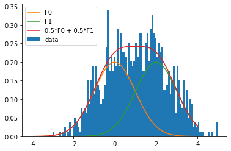

```python
histogram_and_densities()
```

The histogram is quite similar to the mix of the two Gaussians, and the mixed-Gaussian looks like the addition of the two Gaussians.

section b

The expressions are in the attached PDF value. Here we will answer the question in two ways. The first way is to plot the expressions we got, and the second one is to use BH procedure for getting the given expressions, so that we can see we can get them also in an empirical way.

```python
def fdr_expressions(rho=0):
    z, p_vals = generate_data_and_pvals(rho=rho)
    plt.plot(z, p_vals / (p_vals + norm.sf(z-2)), 'o', label='FDR')
    plt.plot(z, 1 / (1 + np.exp(2 * (z-1))), 'o', label='fdr')
    plt.title("FDR vs. fdr expressions")
    plt.legend()
    plt.show()
```

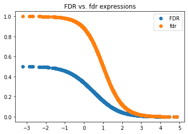

```python
fdr_expressions()
```

In the second way, we calculate the values of the given expressions, using BH procedure. For the fdr, we didn't ask for strict equation but only to close up to epsilon. The graphs are plotted below, and we can see that they are quite close to the graphs that were computed by using the expressions.

```python
def fdr_empirical(rho=0):
    epsilon = 0.5
    x, p_vals = generate_data_and_pvals(rho=rho)
    z = np.linspace(-4, 4, m)[:, np.newaxis]

    FDRs_mat = np.broadcast_to(x, (z.size, x.size)) > z
    fdrs_mat = np.logical_and(np.broadcast_to(x, (z.size, x.size)) > z -
                              epsilon, np.broadcast_to(x, (z.size, x.size)) < z + epsilon)

    for i, mat in enumerate([FDRs_mat, fdrs_mat]):
        r = np.maximum(np.sum(mat, axis=1), 1)
        v = np.sum(mat[:, :m0], axis=1)
        q = v / r
        z = z[np.where(~np.isnan(q))]
        q = q[~np.isnan(q)]
        plt.plot(z, q, 'o', label='FDR' if i == 0 else 'fdr')

    plt.title("FDR vs. fdr empirical")
    plt.legend()
    plt.show()
```

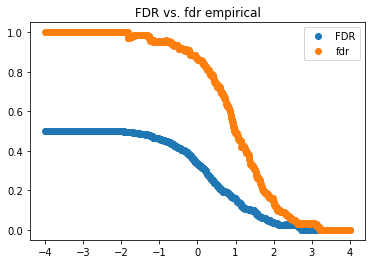

```python
fdr_empirical()
```

section c

```python
def q_values(rho=0, pi_0=0.5):
    x, p_vals = generate_data_and_pvals(rho=rho)
    sorted_p_vals = np.sort(p_vals)
    q_vals = np.minimum((sorted_p_vals * m) / np.arange(1, m+1), 1)
    for i in range(m-2, -1, -1):
        q_vals[i] = min(q_vals[i], q_vals[i+1])
    z = -norm.ppf(sorted_p_vals)

    plt.plot(z, pi_0 * q_vals, 'o', label="pi_0*q_values")
    fdr_expressions()
```

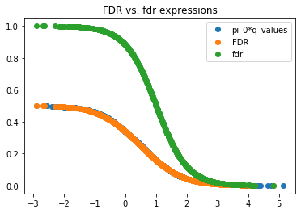

```python
q_values()
```

The FDR and q_values graphs overlap each other, and that's make sense, beacuse we saw that the BH guarantee control in level of αpi_0, and here q_i is the minimal level such that the BH procedure with parameter α will reject the 𝑖-th hypothesis. We can also conclude that we can use the q_value method for estimating the FDR.